## Bibliotecas e Configurações

```python
import os
import urllib.request

import re
import numpy as np
import pandas as pd
import seaborn as sns
import matplotlib.pyplot as plt
from IPython.display import display
```

```python
pd.set_option ('max_colwidth', 100)
#pd.options.display.max_columns = None

sns.set(font_scale=1.4)
sns.set_style({'font.family': 'serif','fontname': 'Times New Roman'})
```

## Carregar DataFrame

```python
list_version=['nvi','nvt','ara','naa','acf','arc','tb','vc','akjv']

version='nvi'
#version=list_version[0]

DataFrame_csv='Vers_Biblia_'+version+'.csv'
url='https://raw.githubusercontent.com/jonathanAmancioSales/Data-Analysis_Bible/main/Data_csv/'+DataFrame_csv

if not os.path.exists(DataFrame_csv):
  File = urllib.request.urlretrieve(url, DataFrame_csv)
```

```python
df = pd.read_csv(DataFrame_csv, index_col=0)
```

### Correções:

- corrigir numeral: [1. 234 -> 1234] {na NVI}

```python
def Search(padrao,st):
  r=re.search(padrao,st)
  if r!=None:
    return r.group(0)
  else:
    return '0'
```

```python
if version=='nvi':
  df['vers']=df['vers'].map(lambda txt: re.sub(re.escape( Search('\d{1}\. \d{1}',txt)[1:-1] ), '',txt))
df.loc[12433, ['vers']]   #Ne 7:12
```

```
vers    de Elão 1254
Name: 12433, dtype: object
```

## Adicionar colunas ao Dataframe

```python
AlfaNumericPt='0-9a-zA-Zá-úÁ-ÚâêôÂÊÔàÀãõÃÕçÇ'
```

```python
#Quebrar palavras com hífen e separar todas as palavras:
list_word_vers=df['vers'].map( lambda v: v.replace('-',' ').split(' ') )

#Remover caracteres não alfanuméricos (português):
list_word_vers=list_word_vers.map( lambda lista: [re.sub('[^'+AlfaNumericPt+']+','',w) for w in lista] )

#Remover elementos vazios (resultantes de caracteres especiais isolados):
list_word_vers=list_word_vers.map( lambda lista: list(filter(lambda w: w!='', lista)) )

display(list_word_vers.head())

df['n_words']=list_word_vers.map( lambda lista: len(lista) )
```

```
0                                                    [No, princípio, Deus, criou, os, céus, e, a, terra]
1    [Era, a, terra, sem, forma, e, vazia, trevas, cobriam, a, face, do, abismo, e, o, Espírito, de, ...
2                                                                [Disse, Deus, Haja, luz, e, houve, luz]
3                                    [Deus, viu, que, a, luz, era, boa, e, separou, a, luz, das, trevas]
4    [Deus, chamou, à, luz, dia, e, às, trevas, chamou, noite, Passaram, se, a, tarde, e, a, manhã, e...
Name: vers, dtype: object
```

```python
#Remoção de caracteres não alfanuméricos para contagem das letras
df['n_letras']=df['vers'].map( lambda txt: len(re.sub('[^'+AlfaNumericPt+']+', '', txt)) )
```

```python
#Criar coluna ref ('livro'+'n_cap'+'n_vers'):
df['ref']=df['livro'].map(lambda name: name.capitalize())+' '+df['n_cap'].map(lambda n: str(n))+':'+df['n_vers'].map(lambda n: str(n))
```

## Visualizar DataFrame e informações

O dataframe df é uma tabela que contém todos os versículos de uma versão específica da Bíblia. Ele contém as seguintes informações:

- vers: texto/conteúdo do versículo (é o versículo propriamente dito);
- n_vers: número do versículo;
- n_cap: número do capítulo a que pertence o versículo;
- livro: nome abreviado do livro a que pertence o versículo;
- livro_name: nome do livro a que pertence o versículo;
- testamento: categoria (AT/NT) a que pertence um livro;
- n_words: número/quantidade de palavras do versículo;
- n_letras: número/quantidade de letras (caracteres alfanuméricos+[vogais acentuadas, ç]) do versículo;
- ref: referência do versículo (livro+n_cap+n_vers).

```python
df
```

|  | testamento | livro_name | livro | n_cap | n_vers | vers | n_words | n_letras | ref |
| --- | --- | --- | --- | --- | --- | --- | --- | --- | --- |
| 0 | AT | Gênesis | gn | 1 | 1 | No princípio Deus criou os céus e a terra. | 9 | 33 | Gn 1:1 |
| 1 | AT | Gênesis | gn | 1 | 2 | Era a terra sem forma e vazia; trevas cobriam a face do abismo, e o Espírito de Deus se movia so... | 25 | 90 | Gn 1:2 |
| 2 | AT | Gênesis | gn | 1 | 3 | Disse Deus: "Haja luz", e houve luz. | 7 | 25 | Gn 1:3 |
| 3 | AT | Gênesis | gn | 1 | 4 | Deus viu que a luz era boa, e separou a luz das trevas. | 13 | 41 | Gn 1:4 |
| 4 | AT | Gênesis | gn | 1 | 5 | Deus chamou à luz dia, e às trevas chamou noite. Passaram-se a tarde e a manhã; esse foi o prime... | 22 | 79 | Gn 1:5 |
| ... | ... | ... | ... | ... | ... | ... | ... | ... | ... |
| 31100 | NT | Apocalipse | ap | 22 | 17 | O Espírito e a noiva dizem: "Vem! " E todo aquele que ouvir diga: "Vem! " Quem tiver sede, venha... | 28 | 102 | Ap 22:17 |
| 31101 | NT | Apocalipse | ap | 22 | 18 | Declaro a todos os que ouvem as palavras da profecia deste livro: se alguém lhe acrescentar algo... | 25 | 125 | Ap 22:18 |
| 31102 | NT | Apocalipse | ap | 22 | 19 | Se alguém tirar alguma palavra deste livro de profecia, Deus tirará dele a sua parte na árvore d... | 28 | 122 | Ap 22:19 |
| 31103 | NT | Apocalipse | ap | 22 | 20 | Aquele que dá testemunho destas coisas diz: "Sim, venho em breve! " Amém. Vem, Senhor Jesus! | 15 | 69 | Ap 22:20 |
| 31104 | NT | Apocalipse | ap | 22 | 21 | A graça do Senhor Jesus seja com todos. Amém. | 9 | 35 | Ap 22:21 |

31105 rows × 9 columns

```python
pd.set_option ('max_colwidth', 120)

#Criar coluna ref ('livro'+'n_cap'+'n_vers'):
df[['testamento','ref','vers','n_words','n_letras']].sample(8)
```

|  | testamento | ref | vers | n_words | n_letras |
| --- | --- | --- | --- | --- | --- |
| 9482 | AT | 1rs 22:1 | Durante três anos não houve guerra entre a Síria e Israel. | 11 | 47 |
| 4492 | AT | Nm 26:3 | Nas campinas de Moabe, junto ao Jordão, do outro lado de Jericó, Moisés e o sacerdote Eleazar falaram com eles e dis... | 22 | 97 |
| 30270 | NT | Tg 1:3 | pois vocês sabem que a prova da sua fé produz perseverança. | 11 | 48 |
| 13961 | AT | Sl 3:3 | Mas tu, Senhor, és o escudo que me protege; és a minha glória e me fazes andar de cabeça erguida. | 20 | 74 |
| 5952 | AT | Js 6:3 | Marche uma vez ao redor da cidade, com todos os homens armados. Faça isso durante seis dias. | 17 | 73 |
| 1347 | AT | Gn 44:23 | Todavia disseste a teus servos que se o nosso irmão caçula não viesse conosco, nunca mais veríamos a tua face. | 20 | 89 |
| 6582 | AT | Jz 3:14 | Os israelitas ficaram sob o domínio de Eglom, rei de Moabe, durante dezoito anos. | 14 | 65 |
| 8820 | AT | 1rs 3:3 | Salomão amava o Senhor, pois andava de acordo com os decretos do seu pai Davi; todavia oferecia sacrifícios e queima... | 24 | 122 |

```python
df.info()
```

```
<class 'pandas.core.frame.DataFrame'>
Int64Index: 31105 entries, 0 to 31104
Data columns (total 9 columns):
 #   Column      Non-Null Count  Dtype
---  ------      --------------  -----
 0   testamento  31105 non-null  object
 1   livro_name  31105 non-null  object
 2   livro       31105 non-null  object
 3   n_cap       31105 non-null  int64
 4   n_vers      31105 non-null  int64
 5   vers        31105 non-null  object
 6   n_words     31105 non-null  int64
 7   n_letras    31105 non-null  int64
 8   ref         31105 non-null  object
dtypes: int64(4), object(5)
memory usage: 3.6+ MB
```

```python
df.describe()
```

|  | n_cap | n_vers | n_words | n_letras |
| --- | --- | --- | --- | --- |
| count | 31105.000000 | 31105.000000 | 31105.000000 | 31105.000000 |
| mean | 20.630317 | 17.044173 | 21.995660 | 96.296126 |
| std | 23.407628 | 14.075402 | 9.572072 | 41.975582 |
| min | 1.000000 | 1.000000 | 1.000000 | 5.000000 |
| 25% | 6.000000 | 7.000000 | 15.000000 | 65.000000 |
| 50% | 14.000000 | 14.000000 | 20.000000 | 90.000000 |
| 75% | 26.000000 | 23.000000 | 28.000000 | 122.000000 |
| max | 150.000000 | 176.000000 | 83.000000 | 393.000000 |

```python
df.describe(include='object')
```

|  | testamento | livro_name | livro | vers | ref |
| --- | --- | --- | --- | --- | --- |
| count | 31105 | 31105 | 31105 | 31105 | 31105 |
| unique | 2 | 66 | 66 | 30677 | 31105 |
| top | AT | Salmos | sl | O Senhor disse a Moisés: | Sl 59:15 |
| freq | 23146 | 2461 | 2461 | 20 | 1 |

```python
#Todos os livros:
#print( df['livro'].unique() )
print( df['livro_name'].unique() )
```

```
['Gênesis' 'Êxodo' 'Levítico' 'Números' 'Deuteronômio' 'Josué' 'Juízes'
 'Rute' '1 Samuel' '2 Samuel' '1 Reis' '2 Reis' '1 Crônicas' '2 Crônicas'
 'Esdras' 'Neemias' 'Ester' 'Jó' 'Salmos' 'Provérbios' 'Eclesiastes'
 'Cânticos' 'Isaías' 'Jeremias' 'Lamentações' 'Ezequiel' 'Daniel' 'Oséias'
 'Joel' 'Amós' 'Obadias' 'Jonas' 'Miquéias' 'Naum' 'Habacuque' 'Sofonias'
 'Ageu' 'Zacarias' 'Malaquias' 'Mateus' 'Marcos' 'Lucas' 'João' 'Atos'
 'Romanos' '1 Coríntios' '2 Coríntios' 'Gálatas' 'Efésios' 'Filipenses'
 'Colossenses' '1 Tessalonicenses' '2 Tessalonicenses' '1 Timóteo'
 '2 Timóteo' 'Tito' 'Filemom' 'Hebreus' 'Tiago' '1 Pedro' '2 Pedro'
 '1 João' '2 João' '3 João' 'Judas' 'Apocalipse']
```

```python
pd.set_option ('max_colwidth', 140)

#Livros agrupados por testamento
display( df.groupby(by=['testamento'])['livro'].unique() )
```

```
testamento
AT    [gn, ex, lv, nm, dt, js, jz, rt, 1sm, 2sm, 1rs, 2rs, 1cr, 2cr, ed, ne, et, jó, sl, pv, ec, ct, is, jr, lm, ez, dn, os, jl, am, ob, jn, m...
NT                      [mt, mc, lc, jo, atos, rm, 1co, 2co, gl, ef, fp, cl, 1ts, 2ts, 1tm, 2tm, tt, fm, hb, tg, 1pe, 2pe, 1jo, 2jo, 3jo, jd, ap]
Name: livro, dtype: object
```

## Criar DataFrame adicional

O dataframe DF_n é uma tabela que contém as seguintes informações por livro da Bíblia:

- livro: nome abreviado dos livros da Bíblia;
- livro_name: nome dos livros da Bíblia;
- total_cap: número/quantidade total de capítulos de um livro;
- total_vers: número/quantidade total de versículos de um livro;
- total_words: número/quantidade total de palavras de um livro;
- total_letras: número/quantidade total de letras de um livro;
- categoria: categoria a que pertence um livro;
- testamento: testamento (AT/NT) a que pertence um livro.

```python
#Número de capítulos por livro/livro_name:
W=df.groupby(by=['livro'])['n_cap'].max()
DF_n=W.to_frame();
DF_n=DF_n.reindex( df['livro'].unique() )
DF_n=DF_n.rename(columns={'n_cap':'total_cap'})
DF_n.reset_index(level=0, inplace=True)
DF_n['livro_name']=df['livro_name'].unique()

#Número de versículos por livro:
v=df.value_counts('livro').to_frame().reindex( df['livro'].unique() )
v.reset_index(level=0, inplace=True)
DF_n['total_vers']=v[0]

#Número de palavras por livro:
w=df.groupby(by=['livro'])['n_words'].sum().to_frame().reindex( df['livro'].unique() )
w.reset_index(level=0, inplace=True)
DF_n['total_words']=w['n_words']

#Número de letras por livro:
l=df.groupby(by=['livro'])['n_letras'].sum().to_frame().reindex( df['livro'].unique() )
l.reset_index(level=0, inplace=True)
DF_n['total_letras']=l['n_letras']

#Testamento:
t=df.groupby(by=['livro'])['testamento'].unique().to_frame().reindex( df['livro'].unique() )
t.reset_index(level=0, inplace=True)
DF_n['testamento']=t['testamento'].map(lambda lista: lista[0])

#Organizar colunas:
cols=DF_n.columns.tolist()
#cols=cols[-1:] + cols[:-1]
cols=['testamento','livro_name','livro','total_cap','total_vers','total_words','total_letras']
DF_n=DF_n[cols]

#Criar atributo 'categoria' dos livros:
Categoria=['Pentateuco', 'Histórico', 'Poético', 'Profetas maiores', 'Profetas menores', 'Evangelho', 'Epístola', 'Revelação']
DF_n['categoria']=''
DF_n.loc[0:4,  'categoria']=Categoria[0]
DF_n.loc[5:16, 'categoria']=Categoria[1]
DF_n.loc[17:21,'categoria']=Categoria[2]
DF_n.loc[22:26,'categoria']=Categoria[3]
DF_n.loc[27:38,'categoria']=Categoria[4]
DF_n.loc[39:42,'categoria']=Categoria[5]
DF_n.loc[43,   'categoria']=Categoria[1]
DF_n.loc[44:64,'categoria']=Categoria[6]
DF_n.loc[65,   'categoria']=Categoria[7]

display(DF_n)
```

|  | testamento | livro_name | livro | total_cap | total_vers | total_words | total_letras | categoria |
| --- | --- | --- | --- | --- | --- | --- | --- | --- |
| 0 | AT | Gênesis | gn | 50 | 1533 | 32974 | 138605 | Pentateuco |
| 1 | AT | Êxodo | ex | 40 | 1213 | 26913 | 116407 | Pentateuco |
| 2 | AT | Levítico | lv | 27 | 859 | 19937 | 88278 | Pentateuco |
| 3 | AT | Números | nm | 36 | 1288 | 26750 | 119947 | Pentateuco |
| 4 | AT | Deuteronômio | dt | 34 | 959 | 24392 | 104382 | Pentateuco |
| ... | ... | ... | ... | ... | ... | ... | ... | ... |
| 61 | NT | 1 João | 1jo | 5 | 105 | 2270 | 9475 | Epístola |
| 62 | NT | 2 João | 2jo | 1 | 13 | 286 | 1218 | Epístola |
| 63 | NT | 3 João | 3jo | 1 | 15 | 297 | 1245 | Epístola |
| 64 | NT | Judas | jd | 1 | 25 | 601 | 2948 | Epístola |
| 65 | NT | Apocalipse | ap | 22 | 405 | 10648 | 44590 | Revelação |

66 rows × 8 columns

## Análise dos números de versículos e capítulos

```python
#Número de versículos dividido por Testamento:
df.value_counts('testamento')
```

```
testamento
AT    23146
NT     7959
dtype: int64
```

```python
#Número de versículos dividido por livro:
#df.value_counts('livro')
#df['livro'].value_counts()

#Número de versículos dividido por livro, agrupado por testamento:
df.groupby(by=['testamento'])['livro'].value_counts()
```

```
testamento  livro
AT          sl       2461
            gn       1533
            jr       1364
            is       1292
            nm       1288
                     ...
NT          tt         46
            fm         25
            jd         25
            3jo        15
            2jo        13
Name: livro, Length: 66, dtype: int64
```

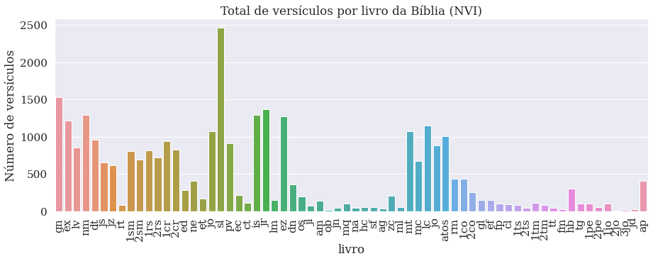

```python
plt.figure(figsize=(15,5))
sns.countplot(data=df, x='livro')
plt.xticks(rotation=90); plt.ylabel('Número de versículos')
plt.title(f'Total de versículos por livro da Bíblia ({version.upper()})')
plt.show()
```

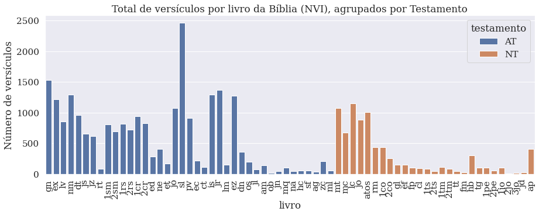

```python
plt.figure(figsize=(15,5))
sns.countplot(data=df, x='livro', hue='testamento', dodge=False)
plt.xticks(rotation=90); plt.ylabel('Número de versículos')
plt.title(f'Total de versículos por livro da Bíblia ({version.upper()}), agrupados por Testamento')
plt.show()
```

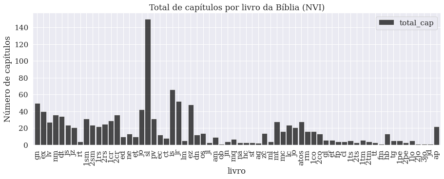

```python
DF_n.plot(x='livro', y='total_cap', kind='bar', width=0.9,
          title=f'Total de capítulos por livro da Bíblia ({version.upper()})',
          color='black',
          #title=f'Total de capítulos por livro da Bíblia ({version.upper()}), agrupados por Testamento',
          #color=list(np.where(DF_n['testamento']=='AT', 'green', 'red')),
          alpha=0.7, rot=90, figsize=(15,5), ylabel='Número de capítulos');
```

## Análise dos números de letras e palavras

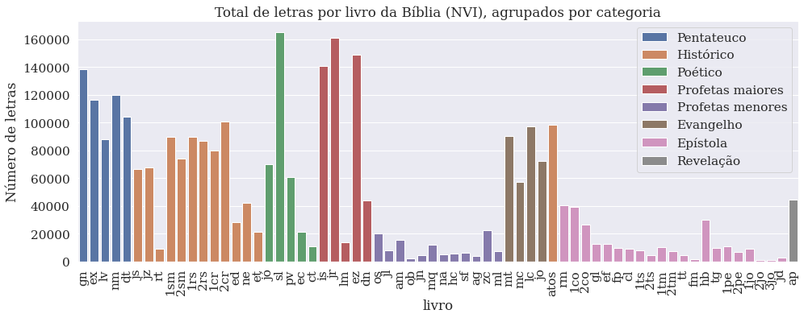

```python
plt.figure(figsize=(16,5.5))
Y='total_letras'; Ylabel='Número de letras';
#Y='total_words'; Ylabel='Número de palavras';
sns.barplot(data=DF_n, x='livro', y=Y, hue='categoria', dodge=False); plt.ylabel(Ylabel)
plt.xticks(rotation=90); plt.legend(loc='upper right')
plt.title(f'Total de letras por livro da Bíblia ({version.upper()}), agrupados por categoria')
plt.show()
```

```python
#Livros com mais letras:
DF_n.loc[DF_n['total_letras']>1.3e5]
```

|  | testamento | livro_name | livro | total_cap | total_vers | total_words | total_letras | categoria |
| --- | --- | --- | --- | --- | --- | --- | --- | --- |
| 0 | AT | Gênesis | gn | 50 | 1533 | 32974 | 138605 | Pentateuco |
| 18 | AT | Salmos | sl | 150 | 2461 | 38307 | 165025 | Poético |
| 22 | AT | Isaías | is | 66 | 1292 | 32273 | 140730 | Profetas maiores |
| 23 | AT | Jeremias | jr | 52 | 1364 | 36489 | 161040 | Profetas maiores |
| 25 | AT | Ezequiel | ez | 48 | 1273 | 34048 | 148823 | Profetas maiores |

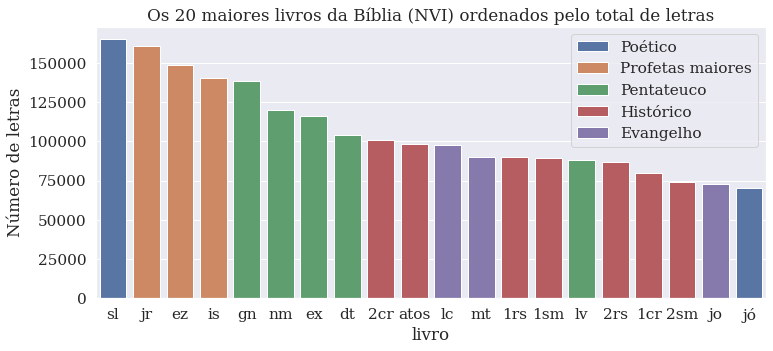

```python
W=DF_n.sort_values('total_letras',ascending=False)

plt.figure(figsize=(12,5))
Y='total_letras'; Ylabel='Número de letras';
sns.barplot(data=W[0:20], x='livro', y=Y, hue='categoria', dodge=False); plt.ylabel(Ylabel)
plt.legend(loc='upper right')
plt.title(f'Os 20 maiores livros da Bíblia ({version.upper()}) ordenados pelo total de letras')
plt.show()
```

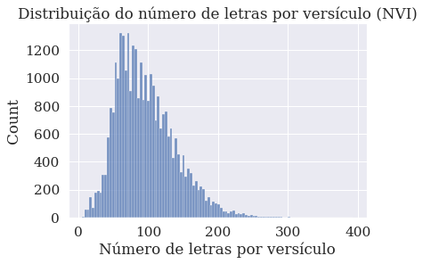

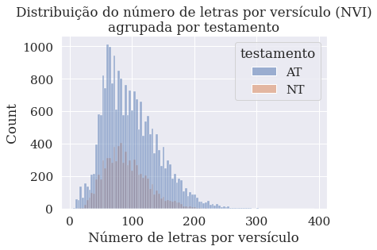

```python
#Distribuição do número de letras por versículo:
sns.histplot(data=df, x='n_letras');
plt.title(f'Distribuição do número de letras por versículo ({version.upper()})')
plt.xlabel('Número de letras por versículo')
plt.show()

sns.histplot(data=df, x='n_letras', hue='testamento')
plt.title(f'Distribuição do número de letras por versículo ({version.upper()})\nagrupada por testamento')
plt.xlabel('Número de letras por versículo')
plt.show()
```

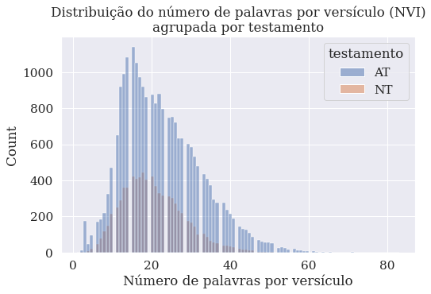

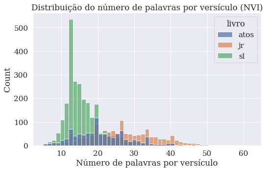

```python
#plt.figure(figsize=(8,5))
#sns.histplot(data=df, x='n_words');
#plt.xlabel('Número de palavras por versículo'); plt.show()

plt.figure(figsize=(8,5))
sns.histplot(data=df, x='n_words',hue='testamento');
plt.xlabel('Número de palavras por versículo')
plt.title(f'Distribuição do número de palavras por versículo ({version.upper()})\nagrupada por testamento')
plt.show()

W=df.loc[df.livro.str.contains('sl|jr|atos'), ['livro','n_words']].sort_index(ascending=False)
plt.figure(figsize=(8.35,5))
sns.histplot(data=W, x='n_words',hue='livro', alpha=0.7);
plt.xlabel('Número de palavras por versículo')
plt.title(f'Distribuição do número de palavras por versículo ({version.upper()})')
plt.show()
```

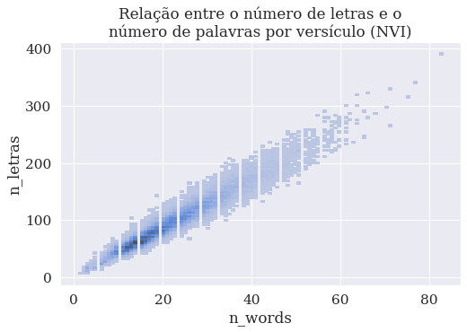

```python
#De fato, é esperado que o número de letras cresça linearmente com o número de palavras.
plt.figure(figsize=(8,5))
sns.histplot(data=df, y='n_letras', x='n_words');
#sns.histplot(data=df, y='n_letras', x='n_words', hue='testamento')
plt.title(f'Relação entre o número de letras e o\nnúmero de palavras por versículo ({version.upper()})')
plt.show()
```

```
R² = 0.9344460764033177
```

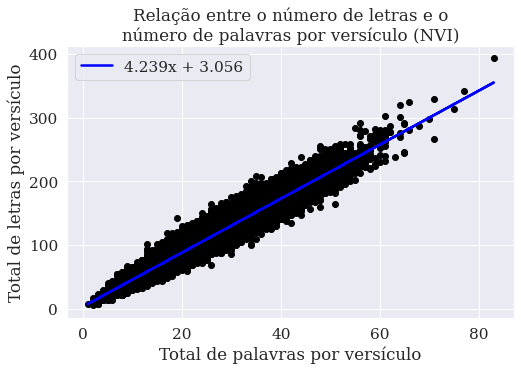

```python
from sklearn.linear_model import LinearRegression

x=df.n_words.values
y=df.n_letras.values

#Filtro=df.testamento=='NT'
#Filtro=df.livro=='sl'
#x=df.loc[Filtro,'n_words'].values
#y=df.loc[Filtro,'n_letras'].values

X=np.array( [[i] for i in x] )
#X[0:10]

reg = LinearRegression().fit(X, y)
print(f'R² = {reg.score(X, y)}\n\n')

y_fit = reg.predict(X)

eq=str( round(reg.coef_[0],3) )+'x + '+str( round(reg.intercept_,3) )

plt.figure(figsize=(8,5))
plt.scatter(X,y, color='black')
plt.plot(X,y_fit, color='blue', linewidth=2.5,label=eq)
plt.title(f'Relação entre o número de letras e o\nnúmero de palavras por versículo ({version.upper()})')
plt.xlabel('Total de palavras por versículo')
plt.ylabel('Total de letras por versículo')
plt.legend()
plt.show()
```

### Maiores e menores versículos

```python
pd.set_option ('max_colwidth', 800)
```

```python
#Versículos com os maiores e menores números de palavras:
display( df.loc[df['n_words']>=75,['ref','vers','n_words']] )
display( df.loc[df['n_words']<3, ['ref','vers']] )
```

|  | ref | vers | n_words |
| --- | --- | --- | --- |
| 12827 | Et 8:9 | Isso aconteceu no dia vinte e três do terceiro mês, o mês de sivã. Os secretários do rei foram imediatamente convocados e escreveram todas as ordens de Mardoqueu aos judeus, aos sátrapas, aos governad… | 77 |
| 21724 | Ez 48:21 | "As terras que restarem em ambos os lados da área formada pela porção sagrada e pela cidade pertencerão ao príncipe. Elas se estenderão para o leste a partir dos doze quilômetros e meio da porção sagr… | 83 |
| 21898 | Dn 5:23 | Pelo contrário, tu te exaltaste acima do Senhor dos céus. Mandaste trazer as taças do templo do Senhor para que nelas bebessem tu, os teus nobres, as tuas mulheres e as tuas concubinas. Louvaste os de… | 75 |

|  | ref | vers |
| --- | --- | --- |
| 2064 | Ex 20:13 | "Não matarás. |
| 2065 | Ex 20:14 | "Não adulterarás. |
| 2066 | Ex 20:15 | "Não furtarás. |
| 3791 | Nm 4:48 | somavam 8580. |
| 4698 | Nm 31:34 | 61000 jumentos |
| 4709 | Nm 31:45 | 30500 jumentos |
| 5070 | Dt 5:17 | "Não matarás. |
| 5071 | Dt 5:18 | "Não adulterarás. |
| 5072 | Dt 5:19 | "Não furtarás. |
| 6395 | Js 21:14 | Jatir, Estemoa, |
| 6396 | Js 21:15 | Holom, Debir, |
| 10513 | 1cr 6:58 | Hilém, Debir, |
| 12907 | Jó 3:2 | dizendo: |
| 13722 | Jó 35:1 | Eliú prosseguiu: |
| 18368 | Is 37:15 | e orou: |
| 25810 | Lc 20:30 | O segundo |
| 26559 | Jo 11:35 | Jesus chorou. |
| 29639 | 1ts 5:17 | Orem continuamente. |

```python
#Versículos com os maiores e menores números de letras:
display( df.loc[df['n_letras']>320,['ref','vers','n_letras']] )
display( df.loc[df['n_letras']<10, ['ref','vers','n_letras']] )
```

|  | ref | vers | n_letras |
| --- | --- | --- | --- |
| 6035 | Js 8:33 | Todo o Israel, estrangeiros e naturais da terra, com os seus líderes, os seus oficiais e os seus juízes, estavam de pé dos dois lados da arca da aliança do Senhor, diante dos sacerdotes levitas, que a… | 329 |
| 12827 | Et 8:9 | Isso aconteceu no dia vinte e três do terceiro mês, o mês de sivã. Os secretários do rei foram imediatamente convocados e escreveram todas as ordens de Mardoqueu aos judeus, aos sátrapas, aos governad… | 341 |
| 21724 | Ez 48:21 | "As terras que restarem em ambos os lados da área formada pela porção sagrada e pela cidade pertencerão ao príncipe. Elas se estenderão para o leste a partir dos doze quilômetros e meio da porção sagr… | 393 |
| 28925 | 2co 7:8 | Mesmo que a minha carta lhes tenha causado tristeza, não me arrependo. É verdade que a princípio me arrependi, pois percebi que a minha carta os entristeceu, ainda que por pouco tempo. 9 Agora, porém,… | 324 |

|  | ref | vers | n_letras |
| --- | --- | --- | --- |
| 12033 | Ed 2:5 | de Ara 775 | 8 |
| 12036 | Ed 2:8 | de Zatu 945 | 9 |
| 12038 | Ed 2:10 | de Bani 642 | 9 |
| 12043 | Ed 2:15 | de Adim 454 | 9 |
| 12046 | Ed 2:18 | de Jora 112 | 9 |
| 12048 | Ed 2:20 | de Gibar 95 | 9 |
| 12057 | Ed 2:29 | de Nebo 52 | 8 |
| 12431 | Ne 7:10 | de Ara 652 | 8 |
| 12434 | Ne 7:13 | de Zatu 845 | 9 |
| 12441 | Ne 7:20 | de Adim 655 | 9 |
| 12907 | Jó 3:2 | dizendo: | 7 |
| 18368 | Is 37:15 | e orou: | 5 |
| 25810 | Lc 20:30 | O segundo | 8 |

## Análise comparativa entre os atributos

```python
#display( DF_n[['total_cap','total_vers','total_words','total_letras']].agg('sum').to_frame().transpose() )
T=DF_n.agg({'testamento':'nunique','livro':'count','total_cap':'sum',
            'total_vers':'sum','total_words':'sum','total_letras':'sum'}).to_frame().transpose()
display(T)
##print(T.index,'\n\n',T.values,'\n\n',T.columns)

print()
#W=DF_n.groupby(by=['testamento'])[['total_cap','total_vers','total_words','total_letras']].agg('sum')
W=DF_n.groupby(['testamento']).agg({'livro':'count','total_cap':'sum','total_vers':'sum','total_words':'sum','total_letras':'sum'})
display(W)

#print()
#W=DF_n.groupby(['categoria']).agg({'livro':'count','total_cap':'sum','total_vers':'sum','total_words':'sum','total_letras':'sum'})
#display(W)

print()
W=DF_n.groupby(['testamento','categoria']).agg({'livro':'count','total_cap':'sum','total_vers':'sum',
                                                'total_words':'sum','total_letras':'sum'})
display(W)
```

|  | testamento | livro | total_cap | total_vers | total_words | total_letras |
| --- | --- | --- | --- | --- | --- | --- |
| 0 | 2 | 66 | 1189 | 31105 | 684175 | 2995291 |

| testamento | livro | total_cap | total_vers | total_words | total_letras |
| --- | --- | --- | --- | --- | --- |
| AT | 39 | 929 | 23146 | 521683 | 2274710 |
| NT | 27 | 260 | 7959 | 162492 | 720581 |

| testamento | categoria | livro | total_cap | total_vers | total_words | total_letras |
| --- | --- | --- | --- | --- | --- | --- |
| AT | Histórico | 12 | 249 | 7019 | 172294 | 756419 |
|  | Pentateuco | 5 | 187 | 5852 | 130966 | 567619 |
|  | Poético | 5 | 243 | 4785 | 76596 | 328019 |
|  | Profetas maiores | 5 | 183 | 4440 | 116041 | 508368 |
|  | Profetas menores | 12 | 67 | 1050 | 25786 | 114285 |
| NT | Epístola | 21 | 121 | 2768 | 57671 | 259444 |
|  | Evangelho | 4 | 89 | 3779 | 72860 | 318033 |
|  | Histórico | 1 | 28 | 1007 | 21313 | 98514 |
|  | Revelação | 1 | 22 | 405 | 10648 | 44590 |

#### Normalizar os dados

para facilitar a comparação entre os atributos

```python
from sklearn.preprocessing import MinMaxScaler

X=DF_n.values[:,3:-1]

#Normalizar dados:
scaler=MinMaxScaler()
X_norm=scaler.fit_transform(X)

DF_norm=pd.DataFrame( X_norm, columns=DF_n.columns.drop(['livro_name','livro','testamento','categoria']) )
DF_norm[['livro_name','livro','testamento','categoria']]=DF_n[['livro_name','livro','testamento','categoria']]
DF_norm = DF_norm[DF_n.columns]

display(DF_norm)
```

|  | testamento | livro_name | livro | total_cap | total_vers | total_words | total_letras | categoria |
| --- | --- | --- | --- | --- | --- | --- | --- | --- |
| 0 | AT | Gênesis | gn | 0.328859 | 0.620915 | 0.859735 | 0.838713 | Pentateuco |
| 1 | AT | Êxodo | ex | 0.261745 | 0.490196 | 0.700324 | 0.703199 | Pentateuco |
| 2 | AT | Levítico | lv | 0.174497 | 0.345588 | 0.516846 | 0.531479 | Pentateuco |
| 3 | AT | Números | nm | 0.234899 | 0.520833 | 0.696036 | 0.724810 | Pentateuco |
| 4 | AT | Deuteronômio | dt | 0.221477 | 0.386438 | 0.634018 | 0.629790 | Pentateuco |
| ... | ... | ... | ... | ... | ... | ... | ... | ... |
| 61 | NT | 1 João | 1jo | 0.026846 | 0.037582 | 0.052182 | 0.050407 | Epístola |
| 62 | NT | 2 João | 2jo | 0.000000 | 0.000000 | 0.000000 | 0.000000 | Epístola |
| 63 | NT | 3 João | 3jo | 0.000000 | 0.000817 | 0.000289 | 0.000165 | Epístola |
| 64 | NT | Judas | jd | 0.000000 | 0.004902 | 0.008285 | 0.010561 | Epístola |
| 65 | NT | Apocalipse | ap | 0.140940 | 0.160131 | 0.272534 | 0.264775 | Revelação |

66 rows × 8 columns

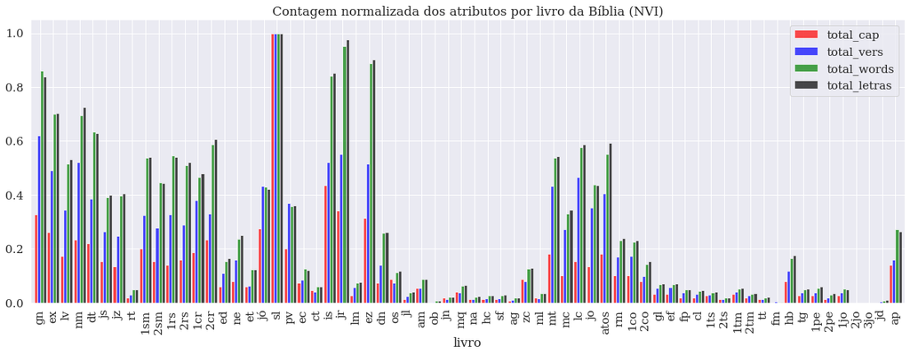

```python
DF_norm.plot(x='livro', y=['total_cap','total_vers','total_words','total_letras'],
             title=f'Contagem normalizada dos atributos por livro da Bíblia ({version.upper()})',
             kind='bar', width=0.92, alpha=0.7, rot=90, figsize=(21,7), color=['red','blue','green','black']);
```

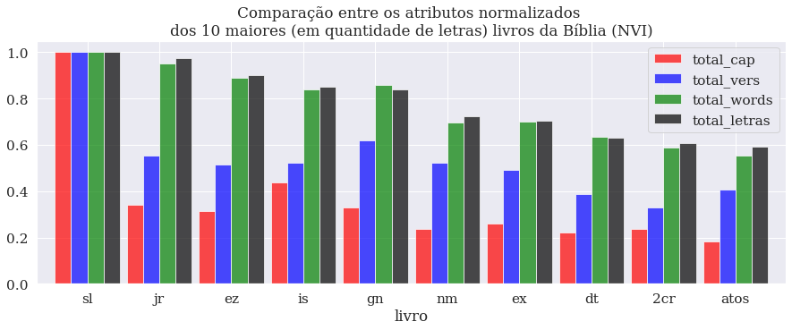

```python
#Os 10 livros com as maiores quantidades de letras:
W=DF_norm.sort_values('total_letras',ascending=False)
W[0:10].plot(x='livro', y=['total_cap','total_vers','total_words','total_letras'],
             title=f'Comparação entre os atributos normalizados \ndos 10 maiores (em quantidade de letras) livros da Bíblia ({version.upper()})',
             kind='bar', width=0.9, alpha=0.7, rot=0, figsize=(15,5), color=['red','blue','green','black']);
```

## Análise da frequência das palavras

### - De toda a Bíblia:

```python
#Lista com todas as palavras por livro:

A=list_word_vers.to_frame()
A['livro']=df['livro']

list_word_livro=[]
for livro in A.livro.unique():
  temp=[]
  for lista in A.loc[A.livro==livro,'vers'].values:
    temp+=lista
  list_word_livro.append(temp)

#print(list_word_livro[7])
```

```python
#Juntar todas as palavras de todos os versículos em uma única lista:
All_Words=[]
#for lista in list_word_vers: All_Words+=lista
for lista in list_word_livro: All_Words+=lista

print(All_Words[2000:2016])

#Criar DataFrame:
Words_df=pd.DataFrame(All_Words,columns=['word'])
Words_df['word']=Words_df['word'].map( lambda w: w.lower() )

print( len(Words_df) )
display( Words_df.tail() )
```

```
['ele', 'deseja', 'conquistá', 'lo', 'mas', 'você', 'deve', 'dominá', 'lo', 'Disse', 'porém', 'Caim', 'a', 'seu', 'irmão', 'Abel']
684175
```

|  | word |
| --- | --- |
| 684170 | jesus |
| 684171 | seja |
| 684172 | com |
| 684173 | todos |
| 684174 | amém |

```python
Words_count=Words_df.value_counts().to_frame()

Words_count.reset_index(level=0, inplace=True)
Words_count=Words_count.rename(columns={0:'count'})

#Remover palavras vazias (word==''):
#Words_count=Words_count.drop( Words_count.loc[Words_count['word']==''].index )
#Words_count=Words_count.sort_values(by=['count'], ignore_index=True, ascending=False)

Words_count
```

|  | word | count |
| --- | --- | --- |
| 0 | e | 29124 |
| 1 | o | 27230 |
| 2 | de | 24801 |
| 3 | a | 20687 |
| 4 | que | 19630 |
| ... | ... | ... |
| 24149 | helefe | 1 |
| 24150 | helcai | 1 |
| 24151 | helbom | 1 |
| 24152 | helba | 1 |
| 24153 | 100 | 1 |

24154 rows × 2 columns

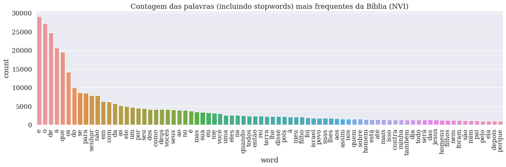

```python
#As 80 palavras (incluindo stopwords) mais frequentes na Bíblia:
plt.figure(figsize=(20,5))
sns.barplot(data=Words_count[0:80], x='word', y='count')
plt.xticks(rotation=90);
plt.title(f'Contagem das palavras (incluindo stopwords) mais frequentes da Bíblia ({version.upper()})')
plt.show()
```

```python
import nltk
nltk.download('stopwords')
```

```
True
```

```python
#Remover StopWords (palavras consideradas irrelevantes para a análise)

stopwords=nltk.corpus.stopwords.words('portuguese')

add=['agora', 'ainda', 'algum', 'alguma', 'algumas', 'alguns', 'ali', 'ampla', 'amplas',
     'amplo', 'amplos', 'ante', 'antes', 'apenas', 'após', 'aqui', 'assim', 'através',
     'cada', 'chegou', 'conforme', 'contra', 'contudo', 'daquele', 'dá', 'dar', 'desde',
     'dessa', 'dessas', 'desse', 'desses', 'desta', 'destas', 'deste', 'destes', 'deu',
     'deve', 'devem', 'devendo', 'dever', 'deveria', 'deveriam', 'deverá', 'deverão',
     'devia', 'deviam', 'diante', 'digo', 'disse', 'disseram', 'disso', 'disto', 'dito',
     'diz', 'dizem', 'dizendo', 'dizer', 'dizia',
     'ei', 'eis', 'embora', 'enquanto', 'então', 'enviou', 'és',
     'falar', 'fará', 'farei', 'faz', 'faze', 'fazendo', 'fazer', 'faça', 'façam',
     'façamos', 'feita', 'feitas', 'feito', 'feitos', 'fez', 'ficou', 'fiz', 'fizeram',
     'fizeste', 'havia', 'haviam', 'ia', 'ir', 'junto',
     'la', 'levaram', 'levou', 'lo', 'los', 'lá', 'jamais', 'mesma', 'mesmas', 'mesmos',
     'mim', 'muita', 'muitas', 'muitos', 'nela', 'nele', 'nenhum', 'nessa', 'nessas',
     'nesta', 'nestas', 'nunca', 'onde', 'outra', 'outras', 'per', 'perante', 'perguntou',
     'pode', 'podem', 'podemos', 'podendo', 'poder', 'poderia', 'poderiam', 'poderá',
     'podes', 'podia', 'podiam', 'pois', 'porquanto', 'porque', 'porém', 'posso', 'pouca',
     'poucas', 'pouco', 'poucos', 'pô', 'pôs', 'própria', 'próprias', 'próprio', 'próprios',
     'pude', 'quais', 'qualquer', 'quanto', 'quantos', 'quer', 'respondeu', 'saiu', 'sei',
     'sempre', 'senão', 'sendo', 'ser', 'serem', 'serão', 'si', 'sido', 'sob', 'sobre',
     'somente', 'talvez', 'tampouco', 'tanto', 'tão', 'tendo', 'ter', 'ti', 'tido',
     'toda', 'todas', 'todavia', 'todo', 'todos', 'tudo', 'têm',
     'umas', 'uns', 'vai', 'veio', 'vem', 'vendo', 'ver', 'vez',
     'vieram', 'vindo', 'vir', 'viram', 'visto', 'viu', 'voltou', 'vosso', 'vossos' 'vou',
     'vá', 'vão', 'vê', 'vós', 'ó', 'última', 'últimas', 'último', 'últimos']

stopwords=stopwords+add
print(len(stopwords))
#print(stopwords,'\n\n')

#print('vosso' in stopwords)
```

```
408
```

```python
from wordcloud import STOPWORDS  #English

if version=='akjv':
  stopwords=nltk.corpus.stopwords.words('english')
  stopwords+=set(STOPWORDS)
  stopwords=list(set(stopwords))
```

```python
Words_count_n_stopw = Words_count.loc[ Words_count['word'].map( lambda w: w not in stopwords ) ]
Words_count_n_stopw = Words_count_n_stopw.sort_values(by=['count'], ignore_index=True, ascending=False)

Words_count_n_stopw['word']=Words_count_n_stopw['word'].map(lambda name: name.capitalize())

display( Words_count_n_stopw )
```

|  | word | count |
| --- | --- | --- |
| 0 | Senhor | 7903 |
| 1 | Deus | 4167 |
| 2 | Rei | 2349 |
| 3 | Terra | 2309 |
| 4 | Filho | 2151 |
| ... | ... | ... |
| 23768 | Refrescaste | 1 |
| 23769 | Refresque | 1 |
| 23770 | Refrão | 1 |
| 23771 | Refugiado | 1 |
| 23772 | 100 | 1 |

23773 rows × 2 columns

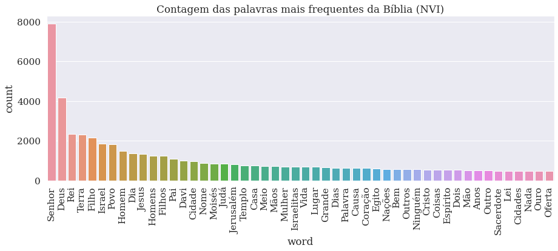

```python
#As 50 palavras mais frequentes na Bíblia:
plt.figure(figsize=(15,5))
sns.barplot(data=Words_count_n_stopw[0:50], x='word', y='count')
plt.xticks(rotation=90);
plt.title(f'Contagem das palavras mais frequentes da Bíblia ({version.upper()})')
plt.show()
```

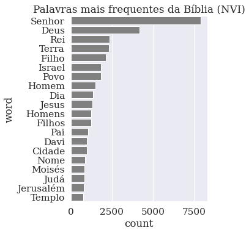

```python
#As palavras mais frequentes na Bíblia:
#plt.figure(figsize=(5,15))
#sns.barplot(data=Words_count_n_stopw[0:60], y='word', x='count')
plt.figure(figsize=(4,5.6))
sns.barplot(data=Words_count_n_stopw[0:20], y='word', x='count', color='gray')
plt.title(f'Palavras mais frequentes da Bíblia ({version.upper()})')
plt.show()
```

### WordCloud

#### - De toda a Bíblia:

```python
from PIL import Image
from wordcloud import WordCloud, ImageColorGenerator
```

```python
# concatenar as palavras
all_summary = " ".join(s for s in All_Words)
```

```python
stopwords=stopwords+[w.capitalize() for w in stopwords]
```

```python
#Gerar wordcloud:
fator=1.7
wordcloud = WordCloud(stopwords=stopwords,
                      background_color='black',
                      #normalize_plurals=False,
                      width=int(fator*1600), height=int(fator*800)).generate(all_summary)
```

```
<wordcloud.wordcloud.WordCloud at 0x7f9168e57b90>
```

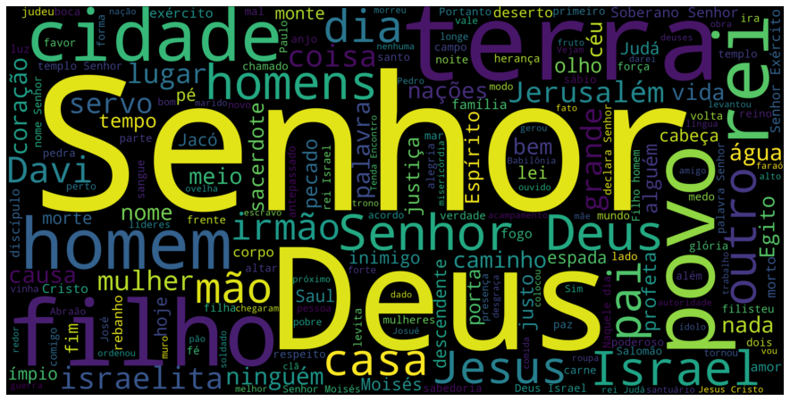

```python
#Exibir imagem:
plt.figure(figsize=(16,8))
plt.imshow(wordcloud.recolor(random_state=2),interpolation="bilinear")
#plt.imshow(wordcloud, interpolation='bilinear')
plt.axis('off')

#Salvar imagem:
file_name='Bible_wordcloud_'+version.upper()
wordcloud.to_file(file_name+'.png')
#wordcloud.to_file(file_name+'.pdf')

#image = wordcloud.to_image(); image.save('a.png')
```

##### Word Cloud - mask image

```python
url='https://drive.google.com/uc?id=19nhGs1ux-IwMyFY_6AsQnfNRX5UlpUwX&export=download'
file_name='Cruz.png'
if not os.path.exists(file_name):
  File = urllib.request.urlretrieve(url, file_name)

image_mask=np.array(Image.open(file_name))
```

```python
#Gerar wordcloud:
fator=1.0
wordcloud = WordCloud(stopwords=stopwords,
                      background_color='black',
                      #normalize_plurals=False,
                      mask=image_mask,
                      width=int(fator*1600), height=int(fator*800)).generate(all_summary)
```

```
<wordcloud.wordcloud.WordCloud at 0x7f9168e472d0>
```

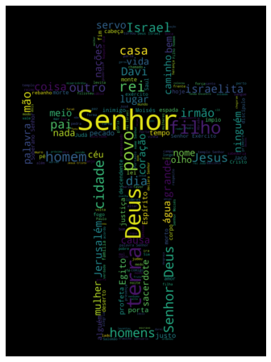

```python
#Exibir imagem:
plt.figure(figsize=(16,8))
plt.imshow(wordcloud.recolor(random_state=2),interpolation="bilinear")
#plt.imshow(wordcloud, interpolation='bilinear')
plt.axis('off')

#Salvar imagem:
file_name='Bible_wordcloud_cruz_'+version.upper()
wordcloud.to_file(file_name+'.png')
```

#### - Por livro:

##### Método 1:

(generate_from_frequencies + nome do livro)

```python
def Wordcloud_Livro_1(id):
  name=DF_n.livro_name.iloc[id]
  ####################
  W=pd.DataFrame(list_word_livro[id],columns=['word'])
  Words_livro_count=W.value_counts().to_frame()

  Words_livro_count.reset_index(level=0, inplace=True)
  Words_livro_count=Words_livro_count.rename(columns={0:'count'})
  ####################
  Words_livro_count_n_stopw = Words_livro_count.loc[ Words_livro_count['word'].map( lambda w: w not in stopwords ) ]
  Words_livro_count_n_stopw = Words_livro_count_n_stopw.sort_values(by=['count'], ignore_index=True, ascending=False)
  ####################
  Dic=Words_livro_count_n_stopw.set_index('word').T.to_dict('records')[0]

  #Adicionar o nome do livro:
  Dic[name]=list(Dic.values())[0]+10
  ####################
  #Gerar wordcloud:
  fator=1.7
  wc = WordCloud(stopwords=stopwords, background_color='black',
                #normalize_plurals=False,
                width=int(fator*1600), height=int(fator*800)).generate_from_frequencies(Dic)

  #plt.figure(figsize=(16,8))
  #plt.imshow(wc.recolor(random_state=2),interpolation="bilinear")
  plt.imshow(wc,interpolation="bilinear")
  plt.axis('off')
  #plt.show()

  file_name='Bible_wordcloud_'+version+'_%02d'%(id+1)+'_'+name+'_1'
  wc.to_file(file_name+'.png')
  ####################
```

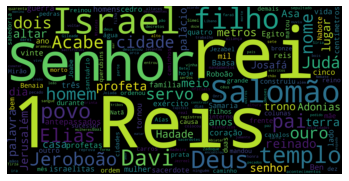

```python
#Index do livro (0-65):
id=10
#id=DF_n.livro.loc[DF_n.livro=='jó'].index[0]

Wordcloud_Livro_1(id)
```

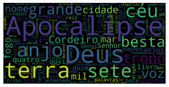

```python
#Criar Word Clouds de todos os livros da Bíblia:
for id in range(66):
  Wordcloud_Livro_1(id)
```

```python
!mkdir wordcloud_img_1
!mv Bible_wordcloud_*_1.png wordcloud_img_1
!zip -r wordcloud_img_1.zip wordcloud_img_1/
```

##### Método 2:

```python
# concatenar as palavras
all_summary_list_livro = [" ".join(s for s in list_word_livro[i]) for i in range(len(list_word_livro))]
```

```python
def Wordcloud_Livro_2(id):
  name=DF_n.livro_name.iloc[id]

  #Gerar wordcloud:
  fator=1.7
  wc = WordCloud(stopwords=stopwords,
                        background_color='black',
                        #normalize_plurals=False,
                        width=int(fator*1600), height=int(fator*800)).generate(all_summary_list_livro[id])

  #plt.figure(figsize=(16,8))
  #plt.imshow(wc.recolor(random_state=2),interpolation="bilinear")
  plt.imshow(wc,interpolation="bilinear")
  plt.axis('off')
  #plt.show()

  file_name='Bible_wordcloud_'+version+'_%02d'%(id+1)+'_'+name+'_2'
  wc.to_file(file_name+'.png')
```

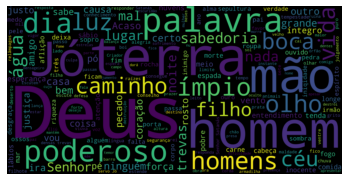

```python
#Index do livro (0-65):
#id=10
id=DF_n.livro.loc[DF_n.livro=='jó'].index[0]

Wordcloud_Livro_2(id)
```

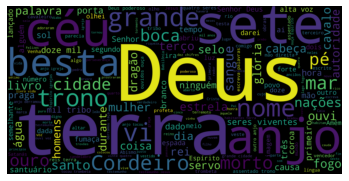

```python
#Criar Word Clouds de todos os livros da Bíblia:
for id in range(66):
  Wordcloud_Livro_2(id)
```

```python
!mkdir wordcloud_img_2
!mv Bible_wordcloud_*_2.png wordcloud_img_2
!zip -r wordcloud_img_2.zip wordcloud_img_2/
```

## Consultas de palavras ou expressões

```python
#Ver capítulo de livro específico:
#display( df.loc[(df['livro']=='sl') & (df['n_cap']==150), ['vers']] )
#OU
display( df.loc[df['ref'].str.contains('Sl 150'), ['vers','ref']] )

#Ver referência específica:
display( df.loc[df['ref']=='Sl 150:1', ['vers']] )
#OU
vers=df.loc[df.ref=='Sl 150:1','vers'].values[0]; print(vers)
```

|  | vers | ref |
| --- | --- | --- |
| 16396 | Aleluia! Louvem a Deus no seu santuário, louvem-no no seu poderoso firmamento. | Sl 150:1 |
| 16397 | Louvem-no pelos seus feitos poderosos, louvem-no segundo a imensidão de sua grandeza! | Sl 150:2 |
| 16398 | Louvem-no ao som de trombeta, louvem-no com a lira e a harpa, | Sl 150:3 |
| 16399 | louvem-no com tamborins e danças, louvem-no com instrumentos de cordas e com flautas, | Sl 150:4 |
| 16400 | louvem-no com címbalos sonoros, louvem-no com címbalos ressonantes. | Sl 150:5 |
| 16401 | Tudo o que tem vida louve o Senhor! Aleluia! | Sl 150:6 |

|  | vers |
| --- | --- |
| 16396 | Aleluia! Louvem a Deus no seu santuário, louvem-no no seu poderoso firmamento. |

```
Aleluia! Louvem a Deus no seu santuário, louvem-no no seu poderoso firmamento.
```

```python
#Pesquisar número de ocorrências de palavra (não de expressão):
display( Words_count_n_stopw.loc[Words_count_n_stopw.word=='Deus'] )  #capitalize
#OU
display( Words_count.loc[Words_count.word=='deus'] )                  #lower
```

|  | word | count |
| --- | --- | --- |
| 1 | Deus | 4167 |

|  | word | count |
| --- | --- | --- |
| 21 | deus | 4167 |

```python
pd.set_option ('max_colwidth', 160)

#Quais/Quantos versículos contêm a expressão requerida (não quantas ocorrências):
expr='Deus'
R=df.loc[df['vers'].str.contains(expr),['ref','vers']]

print(f'Número de versículos que contêm a expressão \"{expr}\": {len(R)}\n')
display(R)
```

```
Número de versículos que contêm a expressão "Deus": 3599
```

|  | ref | vers |
| --- | --- | --- |
| 0 | Gn 1:1 | No princípio Deus criou os céus e a terra. |
| 1 | Gn 1:2 | Era a terra sem forma e vazia; trevas cobriam a face do abismo, e o Espírito de Deus se movia sobre a face das águas. |
| 2 | Gn 1:3 | Disse Deus: "Haja luz", e houve luz. |
| 3 | Gn 1:4 | Deus viu que a luz era boa, e separou a luz das trevas. |
| 4 | Gn 1:5 | Deus chamou à luz dia, e às trevas chamou noite. Passaram-se a tarde e a manhã; esse foi o primeiro dia. |
| ... | ... | ... |
| 31088 | Ap 22:5 | Não haverá mais noite. Eles não precisarão de luz de candeia nem da luz do sol, pois o Senhor Deus os iluminará; e eles reinarão para todo o sempre. |
| 31089 | Ap 22:6 | O anjo me disse: "Estas palavras são dignas de confiança e verdadeiras. O Senhor, o Deus dos espíritos dos profetas, enviou o seu anjo para mostrar aos seus... |
| 31092 | Ap 22:9 | Mas ele me disse: "Não faça isso! Sou servo como você e seus irmãos, os profetas, e como os que guardam as palavras deste livro. Adore a Deus! " |
| 31101 | Ap 22:18 | Declaro a todos os que ouvem as palavras da profecia deste livro: se alguém lhe acrescentar algo, Deus lhe acrescentará as pragas descritas neste livro. |
| 31102 | Ap 22:19 | Se alguém tirar alguma palavra deste livro de profecia, Deus tirará dele a sua parte na árvore da vida e na cidade santa, que são descritas neste livro. |

3599 rows × 2 columns

```python
df.loc[df['vers'].str.contains('Cristo'),['ref','vers']]
```

|  | ref | vers |
| --- | --- | --- |
| 23146 | Mt 1:1 | Registro da genealogia de Jesus Cristo, filho de Davi, filho de Abraão: |
| 23161 | Mt 1:16 | e Jacó gerou José, marido de Maria, da qual nasceu Jesus, que é chamado Cristo. |
| 23162 | Mt 1:17 | Assim, ao todo houve catorze gerações de Abraão a Davi, catorze de Davi até o exílio na Babilônia e catorze do exílio até o Cristo. |
| 23163 | Mt 1:18 | Foi assim o nascimento de Jesus Cristo: Maria, sua mãe, estava prometida em casamento a José, mas, antes que se unissem, achou-se grávida pelo Espírito Santo. |
| 23174 | Mt 2:4 | Tendo reunido todos os chefes dos sacerdotes do povo e os mestres da lei, perguntou-lhes onde deveria nascer o Cristo. |
| ... | ... | ... |
| 30704 | Ap 1:5 | e de Jesus Cristo, que é a testemunha fiel, o primogênito dentre os mortos e o soberano dos reis da terra. Ele que nos ama e nos libertou dos nossos pecados... |
| 30889 | Ap 11:15 | O sétimo anjo tocou a sua trombeta, e houve altas vozes no céu que diziam: "O reino do mundo se tornou de nosso Senhor e do seu Cristo, e ele reinará para t... |
| 30903 | Ap 12:10 | Então ouvi uma forte voz do céu que dizia: "Agora veio a salvação, o poder e o Reino do nosso Deus, e a autoridade do seu Cristo, pois foi lançado fora o ac... |
| 31045 | Ap 20:4 | Vi tronos em que se assentaram aqueles a quem havia sido dada autoridade para julgar. Vi as almas dos que foram decapitados por causa do testemunho de Jesus... |
| 31047 | Ap 20:6 | Felizes e santos os que participam da primeira ressurreição! A segunda morte não tem poder sobre eles; serão sacerdotes de Deus e de Cristo, e reinarão com ... |

510 rows × 2 columns

```python
df.loc[df['vers'].str.contains('Messias'),['ref','vers']]
```

|  | ref | vers |
| --- | --- | --- |
| 26086 | Jo 1:41 | O primeiro que ele encontrou foi Simão, seu irmão, e lhe disse: "Achamos o Messias" ( isto é, o Cristo ). |
| 26182 | Jo 4:25 | Disse a mulher: "Eu sei que o Messias ( chamado Cristo ) está para vir. Quando ele vier, explicará tudo para nós". |
| 26183 | Jo 4:26 | Então Jesus declarou: "Eu sou o Messias! Eu, que estou falando com você". |

```python
#Versículos onde ocorre a palavra 'fé' no livro de Mateus (mt):
W=df[df['livro']=='mt']
W=W.loc[df['vers'].str.contains('fé'),['ref','vers']]

print(f'\nResultados: {len(W)}')
display(W)
```

```
Resultados: 11
```

|  | ref | vers |
| --- | --- | --- |
| 23313 | Mt 6:30 | Se Deus veste assim a erva do campo, que hoje existe e amanhã é lançada ao fogo, não vestirá muito mais a vocês, homens de pequena fé? |
| 23356 | Mt 8:10 | Ao ouvir isso, Jesus admirou-se e disse aos que o seguiam: "Digo-lhes a verdade: Não encontrei em Israel ninguém com tamanha fé. |
| 23372 | Mt 8:26 | Ele perguntou: "Por que vocês estão com tanto medo, homens de pequena fé? " Então ele se levantou e repreendeu os ventos e o mar, e fez-se completa bonança. |
| 23382 | Mt 9:2 | Alguns homens trouxeram-lhe um paralítico, deitado numa cama. Vendo a fé que eles tinham, Jesus disse ao paralítico: "Tenha bom ânimo, filho; os seus pecado... |
| 23402 | Mt 9:22 | Voltando-se, Jesus a viu e disse: "Ânimo, filha, a sua fé a curou! " E desde aquele instante a mulher ficou curada. |
| 23409 | Mt 9:29 | E ele, tocando nos olhos deles, disse: "Que lhes seja feito segundo a fé que vocês têm! " |
| 23629 | Mt 14:31 | Imediatamente Jesus estendeu a mão e o segurou. E disse: "Homem de pequena fé, porque você duvidou? " |
| 23662 | Mt 15:28 | Jesus respondeu: "Mulher, grande é a sua fé! Seja conforme você deseja". E naquele mesmo instante a sua filha foi curada. |
| 23681 | Mt 16:8 | Percebendo a discussão, Jesus lhes perguntou: "Homens de pequena fé, por que vocês estão discutindo entre si sobre não terem pão? |
| 23721 | Mt 17:20 | Ele respondeu: "Por que a fé que vocês têm é pequena. Eu lhes asseguro que se vocês tiverem fé do tamanho de um grão de mostarda, poderão dizer a este monte... |
| 23848 | Mt 21:21 | Jesus respondeu: "Eu lhes asseguro que, se vocês tiverem fé e não duvidarem, poderão fazer não somente o que foi feito à figueira, mas também dizer a este m... |

```python
#Versículos que contém perguntas (?):
df.loc[df['vers'].str.contains('\?'), ['vers','ref']]
```

|  | vers | ref |
| --- | --- | --- |
| 56 | Ora, a serpente era o mais astuto de todos os animais selvagens que o Senhor Deus tinha feito. E ela perguntou à mulher: "Foi isto mesmo que Deus disse: ‘Nã... | Gn 3:1 |
| 64 | Mas o Senhor Deus chamou o homem, perguntando: "Onde está você? " | Gn 3:9 |
| 66 | E Deus perguntou: "Quem lhe disse que você estava nu? Você comeu do fruto da árvore da qual lhe proibi comer? " | Gn 3:11 |
| 68 | O Senhor Deus perguntou então à mulher: "Que foi que você fez? " Respondeu a mulher: "A serpente me enganou, e eu comi". | Gn 3:13 |
| 85 | O Senhor disse a Caim: "Por que você está furioso? Por que se transtornou o seu rosto? | Gn 4:6 |
| ... | ... | ... |
| 30825 | Então um dos anciãos me perguntou: "Quem são estes que estão vestidos de branco, e de onde vieram? " | Ap 7:13 |
| 30915 | Adoraram o dragão, que tinha dado autoridade à besta, e também adoraram a besta, dizendo: "Quem é como a besta? Quem pode guerrear contra ela? " | Ap 13:4 |
| 30953 | Quem não te temerá, ó Senhor? Quem não glorificará o teu nome? Pois tu somente és santo. Todas as nações virão à tua presença e te adorarão, pois os teus at... | Ap 15:4 |
| 30985 | Então o anjo me disse: "Por que você está admirado? Eu lhe explicarei o mistério dessa mulher e da besta sobre a qual ela está montada, que tem sete cabeças... | Ap 17:7 |
| 31014 | Ao verem a fumaça do incêndio dela, exclamarão: ‘Que outra cidade jamais se igualou a esta grande cidade? ’ | Ap 18:18 |

2440 rows × 2 columns

### 'Não temas' e o mito das 365 vezes

```python
#expr='[Nn]ão temer*|[Nn]em temer*'      #'temerei', 'temerão', 'temeram', ...
#expr='[Nn]ão tem[aei]|[Nn]em tem[aei]'  #todas as variações

expr='[Nn]ão tenham* medo|[Nn]em tenham* medo|[Nn]ão tema[ism]*|[Nn]em tema[ism]*'
R=df.loc[df['vers'].str.contains(expr),['ref','vers']]

print(f'{len(R)} vezes na versão {version.upper()}\n')
display(R)
```

```
110 vezes na versão NVI
```

|  | ref | vers |
| --- | --- | --- |
| 361 | Gn 15:1 | Depois dessas coisas o Senhor falou a Abrão numa visão: "Não tenha medo, Abrão! Eu sou o seu escudo; grande será a sua recompensa! " |
| 530 | Gn 21:17 | Deus ouviu o choro do menino, e o anjo de Deus, do céu, chamou Hagar e lhe disse: "O que a aflige, Hagar? Não tenha medo; Deus ouviu o menino chorar, lá ond... |
| 716 | Gn 26:24 | Naquela noite, o Senhor lhe apareceu e disse: "Eu sou o Deus de seu pai Abraão. Não tema, porque estou com você; eu o abençoarei e multiplicarei os seus des... |
| 1028 | Gn 35:17 | E, enquanto padecia muito, tentando dar à luz, a parteira lhe disse: "Não tenha medo, pois você ainda terá outro menino". |
| 1313 | Gn 43:23 | "Fiquem tranqüilos", disse o administrador. "Não tenham medo. O seu Deus, o Deus de seu pai, foi quem lhes deu um tesouro em suas bagagens, porque a prata d... |
| ... | ... | ... |
| 27567 | Atos 18:9 | Certa noite o Senhor falou a Paulo em visão: "Não tenha medo, continue falando e não fique calado, |
| 27880 | Atos 27:24 | ‘Paulo, não tenha medo. É preciso que você compareça perante César; Deus, por sua graça, deu-lhe as vidas de todos os que estão navegando com você’. |
| 30439 | 1pe 3:14 | Todavia, mesmo que venham a sofrer porque praticam a justiça, vocês serão felizes. "Não temam aquilo que eles temem, não fiquem amedrontados. " |
| 30716 | Ap 1:17 | Quando o vi, caí aos seus pés como morto. Então ele colocou sua mão direita sobre mim e disse: "Não tenha medo. Eu sou o primeiro e o último. |
| 30729 | Ap 2:10 | Não tenha medo do que você está prestes a sofrer. Saibam que o diabo lançará alguns de vocês na prisão para prová-los, e vocês sofrerão perseguição durante ... |

110 rows × 2 columns